# Pre-processing with phyloseq

Mar Schmidt

2025-03-12

```r
knitr::opts_chunk$set(echo = TRUE,
                      fig.align = "center",
                      # send any figure output to this folder
                      fig.path = "../figures/02_PreProcessing/")
```

# Goals

The goal with this file is to pre-process any other contaminants and unexpected ASVs from our sample. We will need to:

1. Create a **S4** R data object, which in this case is known as a phyloseq, object from the `asv_table`, `tax_table`, and metadata. This will give us one data object to work with moving forward. :)
2. Remove Chloroplasts.
3. Remove Mitochondria.
4. Removing ASVs from negative controls and also negative control samples.
5. Evaluate accuracy by looking at the Mock Community.
6. Check for reverse complements!
7. Remove samples without “enough” reads.

## Input

Here, we will process the data into a phyloseq object.

1. **Metadata**: We will need `data/metadata.csv` and the file we created and saved from `02_AssignASVs.Rmd` and is located at `data/01_DADA2/track_read_counts.RData`.
2. **ASV table**: We created and saved this file in `02_AssignASVs.Rmd` and it is located at `data/01_DADA2/ASV_table.tsv`.
3. **Taxonomy Table**: We created and saved this file in `02_AssignASVs.Rmd` and it is located at `data/01_DADA2/ASV_taxonomy.tsv`.

## Output

# Set up the Environment

## Set the seeds and threads

```r
# Set the seed for reproducibility
set.seed(238428)
```

## Timing of this script

Let’s record how long this file took to run on the class server, which we will record at the end of the script.

```r
# What time did we start running this script?
start_time <- Sys.time()
```

## Load packages

```r
# We will need BioStrings
#if (!require("BiocManager", quietly = TRUE))
#    install.packages("BiocManager")
#BiocManager::install("Biostrings")

# Now load everything else
pacman::p_load(devtools, phyloseq, Biostrings, tidyverse, dada2, install = FALSE)
```

# Load Data

## 1. Metadata

Before starting this section, let’s copy over the metadata

- Where to copy to? `SalinityGradient_16S/data`
- Where to copy from?: `/workdir/in_class_data/SalinityGradient_16S/metadata.csv`

```r
# Load in the metadata
metadata_df <- read_csv("data/metadata.csv", col_names = TRUE) %>%
  # Add sample names to row names
  rename("sample_names" = "...1") %>%
  # Let's also make a names column which will be used later to more easily access our sample names
  mutate(names = sample_names)
```

```
## ──────────────────────────────────────────────────────── Delimiter: "," chr
## (13): ...1, year, day, project, station, fraction, date, month, X10min_... dbl
## (21): depth, replicate, vol_filtered_mL, DNA_conc1a_nguL, total_uL_DNA,... time
## (4): collection_time, process_time, sitting_time, time
```

```r
# Inspect
head(metadata_df)
```

```
## # A tibble: 6 × 39
##   sample_names  year  day   project station depth replicate fraction date  month
##   <chr>         <chr> <chr> <chr>   <chr>   <dbl>     <dbl> <chr>    <chr> <chr>
## 1 022um-Control 022u  Co    tr      Control   0          NA Control  <NA>  <NA>
## 2 20210602-MA-… 2021  02    MA      Aransa…   2.5         1 Free     6/2/… June
## 3 20210602-MA-… 2021  02    MA      Aransa…   2.5         1 Particle 6/2/… June
## 4 20210602-MA-… 2021  02    MA      Aransa…   2.5         1 Whole    6/2/… June
## 5 20210602-MA-… 2021  02    MA      Aransa…   0           1 Free     6/2/… June
## 6 20210602-MA-… 2021  02    MA      Aransa…   0           1 Particle 6/2/… June
## # ℹ 29 more variables: vol_filtered_mL <dbl>, DNA_conc1a_nguL <dbl>,
## #   total_uL_DNA <dbl>, tot_ng <dbl>, tot_filtration_time <dbl>,
## #   collection_time <time>, process_time <time>, sitting_time <time>,
## #   julian_day <dbl>, total_filter <dbl>, used_filter <dbl>, filter_left <dbl>,
## #   X10min_65 <chr>, dna_kit <chr>, vol_DNAused_16S <dbl>, vol_qPCR <dbl>,
## #   labnote_page <chr>, Sample_or_Control <chr>, time <time>,
## #   water_tempC <dbl>, SpCond_mS <dbl>, salinity_psu <dbl>, pH <dbl>, …
```

```r
dim(metadata_df)
```

```
## [1] 95 39
```

```r
# Then, load in track reads
load("data/01_DADA2/track_read_counts.RData")

# Take a look at the data
head(track_counts_df)
```

```
##                             sample_names denoisedF denoisedR merged nochim
## 1     022um-Control_R1_filtered.fastq.gz      8051      8019   8015   8015
## 2 20210602-MA-ABB1F_R1_filtered.fastq.gz      4451      4391   4226   3534
## 3 20210602-MA-ABB1P_R1_filtered.fastq.gz      4082      4052   3737   3183
## 4 20210602-MA-ABB1W_R1_filtered.fastq.gz      6496      6481   6106   5053
## 5 20210602-MA-ABS1F_R1_filtered.fastq.gz      4233      4242   3960   3249
## 6 20210602-MA-ABS1P_R1_filtered.fastq.gz      4685      4709   4423   3808
##   num_ASVs
## 1        9
## 2      145
## 3      141
## 4      157
## 5      128
## 6      150
```

```r
dim(track_counts_df)
```

```
## [1] 96  6
```

```r
# Wait, the names are filenames!
head(track_counts_df$sample_names)
```

```
## [1] "022um-Control_R1_filtered.fastq.gz"
## [2] "20210602-MA-ABB1F_R1_filtered.fastq.gz"
## [3] "20210602-MA-ABB1P_R1_filtered.fastq.gz"
## [4] "20210602-MA-ABB1W_R1_filtered.fastq.gz"
## [5] "20210602-MA-ABS1F_R1_filtered.fastq.gz"
## [6] "20210602-MA-ABS1P_R1_filtered.fastq.gz"
```

```r
# Fix the names!
track_counts_df$sample_names <- sapply(strsplit(track_counts_df$sample_names, "_"), `[`,1)

# Inspect to make sure it worked!
head(track_counts_df$sample_names)
```

```
## [1] "022um-Control"     "20210602-MA-ABB1F" "20210602-MA-ABB1P"
## [4] "20210602-MA-ABB1W" "20210602-MA-ABS1F" "20210602-MA-ABS1P"
```

```r
# Do they match?
length(track_counts_df$sample_names)
```

```
## [1] 96
```

```r
length(metadata_df$sample_names)
```

```
## [1] 95
```

```r
# It's not true! What's the difference?
#setdiff(track_counts_df$sample_names, metadata_df$sample_names)

# Ohhh, this is an extra sample that accidentally got in.
## Let's remove this sample by using left join, which will only merge with what we have in our metadata!
metadata_final_df <-
  metadata_df %>%
  left_join(., track_counts_df, by = "sample_names") %>%
  # we need our sample names in rownames!
  column_to_rownames(var = "sample_names")

# Intuition check
dim(metadata_final_df)
```

```
## [1] 95 43
```

```r
head(metadata_final_df)
```

```
##                   year day project     station depth replicate fraction   date
## 022um-Control     022u  Co      tr     Control   0.0        NA  Control   <NA>
## 20210602-MA-ABB1F 2021  02      MA Aransas Bay   2.5         1     Free 6/2/21
## 20210602-MA-ABB1P 2021  02      MA Aransas Bay   2.5         1 Particle 6/2/21
## 20210602-MA-ABB1W 2021  02      MA Aransas Bay   2.5         1    Whole 6/2/21
## 20210602-MA-ABS1F 2021  02      MA Aransas Bay   0.0         1     Free 6/2/21
## 20210602-MA-ABS1P 2021  02      MA Aransas Bay   0.0         1 Particle 6/2/21
##                   month vol_filtered_mL DNA_conc1a_nguL total_uL_DNA tot_ng
## 022um-Control      <NA>              NA           0.001           NA     NA
## 20210602-MA-ABB1F  June             360          25.900        44.61   1207
## 20210602-MA-ABB1P  June             360           2.910        34.00    105
## 20210602-MA-ABB1W  June             360          65.300        43.36   2962
## 20210602-MA-ABS1F  June             300          39.700        44.94   1864
## 20210602-MA-ABS1P  June             300          10.400        42.54    463
##                   tot_filtration_time collection_time process_time sitting_time
## 022um-Control                      NA              NA           NA           NA
## 20210602-MA-ABB1F                  20        08:30:00     17:30:00     09:00:00
## 20210602-MA-ABB1P                  20        08:30:00     17:30:00     09:00:00
## 20210602-MA-ABB1W                  20        08:30:00     17:30:00     09:00:00
## 20210602-MA-ABS1F                  20        08:30:00     16:45:00     08:15:00
## 20210602-MA-ABS1P                  20        08:30:00     16:45:00     08:15:00
##                   julian_day total_filter used_filter filter_left X10min_65
## 022um-Control             NA           NA          NA          NA      <NA>
## 20210602-MA-ABB1F        153            1         1.0         0.0        no
## 20210602-MA-ABB1P        153            1         1.0         0.0        no
## 20210602-MA-ABB1W        153            1         1.0         0.0        no
## 20210602-MA-ABS1F        153            1         0.5         0.5       yes
## 20210602-MA-ABS1P        153            1         0.5         0.5       yes
##                      dna_kit vol_DNAused_16S vol_qPCR     labnote_page
## 022um-Control           <NA>              NA       NA             <NA>
## 20210602-MA-ABB1F July26_kit            1.39        2 spilled filtrate
## 20210602-MA-ABB1P July26_kit           12.00        2 spilled filtrate
## 20210602-MA-ABB1W July26_kit            0.64        2             <NA>
## 20210602-MA-ABS1F July26_kit            1.06        2             <NA>
## 20210602-MA-ABS1P July26_kit            3.46        2             <NA>
##                   Sample_or_Control     time water_tempC SpCond_mS salinity_psu
## 022um-Control               Control       NA          NA        NA           NA
## 20210602-MA-ABB1F       True Sample 07:39:00       27.18     27.70        16.97
## 20210602-MA-ABB1P       True Sample 07:39:00       27.18     27.70        16.97
## 20210602-MA-ABB1W       True Sample 07:39:00       27.18     27.70        16.97
## 20210602-MA-ABS1F       True Sample 07:39:00       26.93     27.11        16.58
## 20210602-MA-ABS1P       True Sample 07:39:00       26.93     27.11        16.58
##                     pH turbidity_NTU chlorophyll_ugL percent_DO DO_mgL notes
## 022um-Control       NA            NA              NA         NA     NA  <NA>
## 20210602-MA-ABB1F 8.07          10.9             8.7      105.3   7.62  <NA>
## 20210602-MA-ABB1P 8.07          10.9             8.7      105.3   7.62  <NA>
## 20210602-MA-ABB1W 8.07          10.9             8.7      105.3   7.62  <NA>
## 20210602-MA-ABS1F 8.06           6.2             8.6      104.5   7.58  <NA>
## 20210602-MA-ABS1P 8.06           6.2             8.6      104.5   7.58  <NA>
##                               names denoisedF denoisedR merged nochim num_ASVs
## 022um-Control         022um-Control      8051      8019   8015   8015        9
## 20210602-MA-ABB1F 20210602-MA-ABB1F      4451      4391   4226   3534      145
## 20210602-MA-ABB1P 20210602-MA-ABB1P      4082      4052   3737   3183      141
## 20210602-MA-ABB1W 20210602-MA-ABB1W      6496      6481   6106   5053      157
## 20210602-MA-ABS1F 20210602-MA-ABS1F      4233      4242   3960   3249      128
## 20210602-MA-ABS1P 20210602-MA-ABS1P      4685      4709   4423   3808      150
```

```r
glimpse(metadata_final_df)
```

```
## Rows: 95
## Columns: 43
## $ year                <chr> "022u", "2021", "2021", "2021", "2021", "2021", "2…
## $ day                 <chr> "Co", "02", "02", "02", "02", "02", "02", "02", "0…
## $ project             <chr> "tr", "MA", "MA", "MA", "MA", "MA", "MA", "MA", "M…
## $ station             <chr> "Control", "Aransas Bay", "Aransas Bay", "Aransas …
## $ depth               <dbl> 0.0, 2.5, 2.5, 2.5, 0.0, 0.0, 0.0, 2.0, 2.0, 2.0, …
## $ replicate           <dbl> NA, 1, 1, 1, 1, 1, 1, 1, 1, 1, 1, 1, 1, 1, 1, 1, 1…
## $ fraction            <chr> "Control", "Free", "Particle", "Whole", "Free", "P…
## $ date                <chr> NA, "6/2/21", "6/2/21", "6/2/21", "6/2/21", "6/2/2…
## $ month               <chr> NA, "June", "June", "June", "June", "June", "June"…
## $ vol_filtered_mL     <dbl> NA, 360, 360, 360, 300, 300, 300, 183, 183, 285, 1…
## $ DNA_conc1a_nguL     <dbl> 0.001, 25.900, 2.910, 65.300, 39.700, 10.400, 47.4…
## $ total_uL_DNA        <dbl> NA, 44.61, 34.00, 43.36, 44.94, 42.54, 45.11, 44.8…
## $ tot_ng              <dbl> NA, 1207, 105, 2962, 1864, 463, 2233, 1524, 51, 31…
```

[output cut: 30 more lines]

## 1. ASV Table

```r
# First, load asv table, df = dataframe
asv_df <- read.delim(file = "data/01_DADA2/ASV_table.tsv", sep = "\t",
                        # Add the column & row names
                        header = TRUE, row.names = 1) %>%
  # Remove that extra sample!
  select(-"CJ.V08.P")

# Inspect asv_df
head(asv_df)[,1:5]
```

```
##          X022um.Control X20210602.MA.ABB1F X20210602.MA.ABB1P
## ASV_0001              0                598                417
## ASV_0002              0                248                177
## ASV_0003           7747                 48                  0
## ASV_0004              0                165                165
## ASV_0005              0                 20                 18
## ASV_0006              0                 11                  0
##          X20210602.MA.ABB1W X20210602.MA.ABS1F
## ASV_0001                881                501
## ASV_0002                301                204
## ASV_0003                  0                  0
## ASV_0004                216                112
## ASV_0005                 29                  0
## ASV_0006                  7                  6
```

```r
dim(asv_df)
```

```
## [1] 2919   95
```

```r
# Let's fix sample names, ^X removes an X at the beginning of the name
colnames(asv_df) <- sub("^X", "", colnames(asv_df))
# And fix the "." to be a "-"
  # Note that   "\\." → Matches a literal . (since . is a special character in regex)
colnames(asv_df)  <- gsub("\\.", "-", colnames(asv_df) )

# Inspect asv_df
head(colnames(asv_df)) # Now it looks good!
```

```
## [1] "022um-Control"     "20210602-MA-ABB1F" "20210602-MA-ABB1P"
## [4] "20210602-MA-ABB1W" "20210602-MA-ABS1F" "20210602-MA-ABS1P"
```

```r
head(asv_df)[,1:5]
```

```
##          022um-Control 20210602-MA-ABB1F 20210602-MA-ABB1P 20210602-MA-ABB1W
## ASV_0001             0               598               417               881
## ASV_0002             0               248               177               301
## ASV_0003          7747                48                 0                 0
## ASV_0004             0               165               165               216
## ASV_0005             0                20                18                29
## ASV_0006             0                11                 0                 7
##          20210602-MA-ABS1F
## ASV_0001               501
## ASV_0002               204
## ASV_0003                 0
## ASV_0004               112
## ASV_0005                 0
## ASV_0006                 6
```

## Taxonomy Table

```r
tax_df <- read.delim("data/01_DADA2/ASV_taxonomy.tsv", sep = "\t",
                     # Add the column & row names
                     header = TRUE, row.names = 1)

# Inspect
head(tax_df)
```

```
##           Kingdom          Phylum               Class           Order
## ASV_0001 Bacteria Cyanobacteriota      Cyanobacteriia Synechococcales
## ASV_0002 Bacteria Cyanobacteriota      Cyanobacteriia Synechococcales
## ASV_0003 Bacteria  Pseudomonadota Gammaproteobacteria Pseudomonadales
## ASV_0004 Bacteria  Pseudomonadota Gammaproteobacteria Pseudomonadales
## ASV_0005 Bacteria Cyanobacteriota      Cyanobacteriia Synechococcales
## ASV_0006 Bacteria  Actinomycetota      Actinobacteria      Frankiales
##                    Family                Genus Species      ASV
## ASV_0001     Cyanobiaceae   Cyanobium PCC-6307    <NA> ASV_0001
## ASV_0002     Cyanobiaceae   Cyanobium PCC-6307    <NA> ASV_0002
## ASV_0003 Pseudomonadaceae          Pseudomonas    <NA> ASV_0003
## ASV_0004      SAR86 clade                 <NA>    <NA> ASV_0004
## ASV_0005     Cyanobiaceae Synechococcus CC9902    <NA> ASV_0005
## ASV_0006  Sporichthyaceae           hgcI clade    <NA> ASV_0006
##                                                                                                                                                                                                                                                        ASVseqs
## ASV_0001 GAGTGGCAAGCGTTATCCGGAATTATTGGGCGTAAAGCGTCCGCAGGCGGTCTGTCAAGT…
## ASV_0002 GAGTGGCAAGCGTTATCCGGAATTATTGGGCGTAAAGCGTCCGCAGGCGGTCTTGTAAGT…
## ASV_0003 AGGGTGCAAGCGTTAATCGGAATTACTGGGCGTAAAGCGCGCGTAGGTGGTTCGTTAAGT…
## ASV_0004 AAGGTCCAAGCGTTAATCGGAATTACTGGGCGTAAAGCGCGCGTAGGTGGTTTATTAAGT…
## ASV_0005 GAGTGGCAAGCGTTATCCGGAATTATTGGGCGTAAAGCGTCCGCAGGCGGCCCTTCAAGT…
## ASV_0006 AGGGTGCAAGCGTTGTCCGGAATTATTGGGCGTAAAGAGCTCGTAGGTCGTTTGCCGCGT…
```

```r
dim(tax_df)
```

```
## [1] 2919    9
```

```r
# Add a check to make sure ASV names match each other in the asv_df and the tax_df
stopifnot(rownames(asv_df) == rownames(tax_df))
```

# Handoff to phyloseq

```r
# double check it's all good
dim(asv_df)
```

```
## [1] 2919   95
```

```r
dim(tax_df)
```

```
## [1] 2919    9
```

```r
# The rownames need to between asv and tax tables
head(row.names(asv_df))
```

```
## [1] "ASV_0001" "ASV_0002" "ASV_0003" "ASV_0004" "ASV_0005" "ASV_0006"
```

```r
head(row.names(tax_df))
```

```
## [1] "ASV_0001" "ASV_0002" "ASV_0003" "ASV_0004" "ASV_0005" "ASV_0006"
```

```r
stopifnot(row.names(asv_df) == row.names(tax_df))

# The sample names need to match between metadata and asv tables
head(colnames(asv_df))
```

```
## [1] "022um-Control"     "20210602-MA-ABB1F" "20210602-MA-ABB1P"
## [4] "20210602-MA-ABB1W" "20210602-MA-ABS1F" "20210602-MA-ABS1P"
```

```r
head(row.names(metadata_final_df))
```

```
## [1] "022um-Control"     "20210602-MA-ABB1F" "20210602-MA-ABB1P"
## [4] "20210602-MA-ABB1W" "20210602-MA-ABS1F" "20210602-MA-ABS1P"
```

```r
stopifnot(colnames(asv_df) == row.names(metadata_final_df))

# Construct the phyloseq object
raw_physeq <- phyloseq(otu_table(asv_df, taxa_are_rows = TRUE),
                       sample_data(metadata_final_df),
                       # The taxonomy table needs to first be converted into a matrix
                       tax_table(as.matrix(tax_df)))

# Check the phyloseq object!
raw_physeq
```

```
## phyloseq-class experiment-level object
## otu_table()   OTU Table:         [ 2919 taxa and 95 samples ]
## sample_data() Sample Data:       [ 95 samples by 43 sample variables ]
## tax_table()   Taxonomy Table:    [ 2919 taxa by 9 taxonomic ranks ]
```

```r
# Save this raw phyloseq object
save(raw_physeq, file = "data/02_PreProcessing/raw_physeq.RData")
```

# Clean up the data

Now, we can do some more cleaning! We know that there are organelles in eukaryotes derived from microbes, which still have a 16S that will contaminate our samples. Let’s remove those!

1. Chloroplasts
2. mitochondria

```r
# Let's tak a quick look at the tax table
# View(tax_df) # Let's see where chloroplasts are and also mitochondria

# Make new physeq without chloroplasts
noChloros_physeq <-
  raw_physeq %>%
  # rm chloroplasts, which are Order
  subset_taxa(Order != "Chloroplast" | is.na(Order))

# How many taxa were chloroplasts?
num_chloro_ASVs <- ntaxa(raw_physeq) - ntaxa(noChloros_physeq)
num_chloro_ASVs
```

```
## [1] 250
```

```r
# Intuition chek
#noChloros_physeq %>%
#  tax_table() %>%
#  data.frame() %>%
#  View()

# remove mitochondria
noChlorosMitos_physeq <-
  noChloros_physeq %>%
  subset_taxa(Family != "Mitochondria" | is.na(Family))

# How many mitochondrial ASVs?
num_mito_ASVs <- ntaxa(noChloros_physeq) - ntaxa(noChlorosMitos_physeq)
num_mito_ASVs
```

```
## [1] 30
```

```r
# Let's take a quick look
noChlorosMitos_physeq
```

```
## phyloseq-class experiment-level object
## otu_table()   OTU Table:         [ 2639 taxa and 95 samples ]
## sample_data() Sample Data:       [ 95 samples by 43 sample variables ]
## tax_table()   Taxonomy Table:    [ 2639 taxa by 9 taxonomic ranks ]
```

```r
# How many total asvs were removed from chloros and mitos?
ntaxa(raw_physeq) - ntaxa(noChlorosMitos_physeq)
```

```
## [1] 280
```

```r
# proportion of asvs kept?
ntaxa(noChlorosMitos_physeq)/ntaxa(raw_physeq)
```

```
## [1] 0.9040767
```

# Evaulate and remove the control samples

Now, let’s take a look at the negative controls and then make a decision about whether or not to remove the ASVs that we found in our controls

1. Negative controls
2. ASVs found within the negative controls and their distribution in the samples.
3. Evaluate the mock community

## Negative Controls

```r
# create a vector of samples that were negative controls
control_samples <- c("WaterControl", "022um-Control", "3um-Control", "DNA-Ext-Control")

# Make a new phyloseq object of only the control samples
control_physeq <-
  noChlorosMitos_physeq %>%
  subset_samples(., names %in% control_samples) %>%
  # force remove ASVs with 0 counts
  prune_taxa(taxa_sums(.) > 0, .)

# Let's take a look
control_physeq
```

```
## phyloseq-class experiment-level object
## otu_table()   OTU Table:         [ 28 taxa and 4 samples ]
## sample_data() Sample Data:       [ 4 samples by 43 sample variables ]
## tax_table()   Taxonomy Table:    [ 28 taxa by 9 taxonomic ranks ]
```

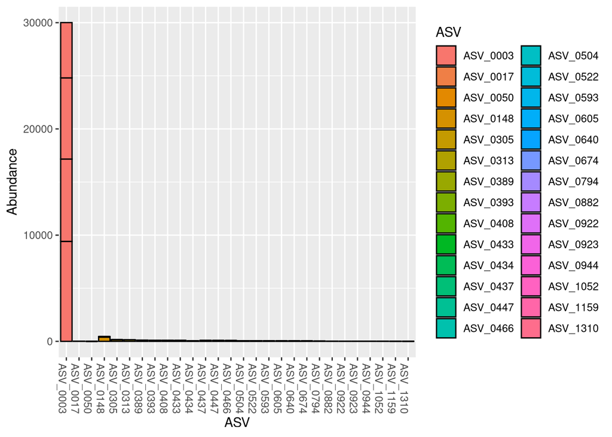

```r
# vector of control asvs
control_ASVs <-
  control_physeq %>%
  tax_table() %>%
  data.frame() %>%
  dplyr::select(ASV) %>%
  as.vector()

# Visualize raw abundance values of control ASVs
control_physeq %>%
  plot_bar(., "ASV", fill = "ASV")
```

```r
############# Check the control ASVs in the samples
# Make new phyloseq object with only the control ASVs and ALL samples
controlASV_physeq <-
  noChlorosMitos_physeq %>%
  subset_taxa(., ASV %in% control_ASVs$ASV)

# Inspect it
controlASV_physeq
```

```
## phyloseq-class experiment-level object
## otu_table()   OTU Table:         [ 28 taxa and 95 samples ]
## sample_data() Sample Data:       [ 95 samples by 43 sample variables ]
## tax_table()   Taxonomy Table:    [ 28 taxa by 9 taxonomic ranks ]
```

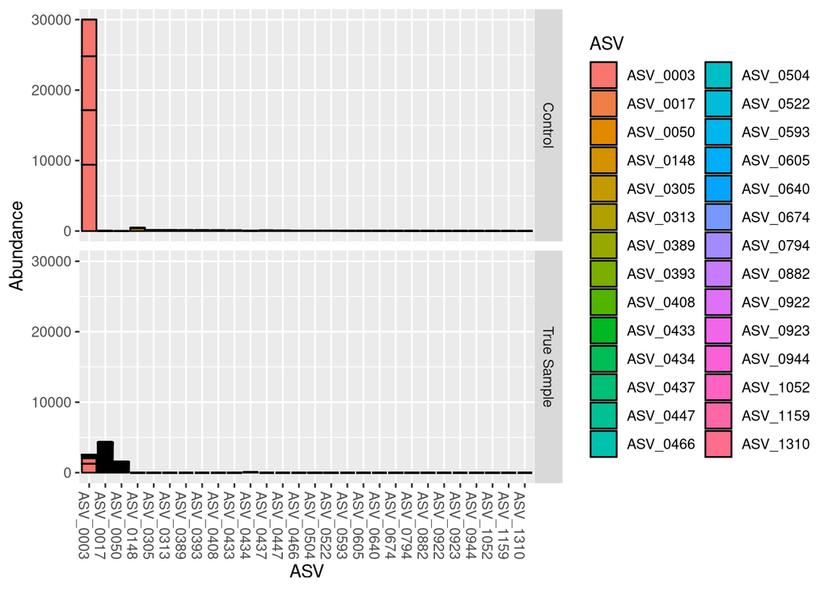

```r
# Let's take a look at the abundances
controlASV_physeq %>%
  plot_bar(., "ASV", fill = "ASV", facet_grid = Sample_or_Control~.)
```

```r
# Check tax of ASV_0003
#controlASV_physeq %>%
#  tax_table() %>%
#  data.frame() %>%
#  View()

# Would only like to keep ASV_18 and ASV_56, everything else is trash
controlASVs_toREMOVE <- dplyr::setdiff(control_ASVs$ASV, c("ASV_0017", "ASV_0050"))
# double check
length(controlASVs_toREMOVE)
```

```
## [1] 26
```

```r
### Make my new phloseq object
noControlsChlorosMitos_physeq <-
  noChlorosMitos_physeq %>%
  # Actually remove the control ASVs (except 18, 56)
  subset_taxa(., !(ASV %in% controlASVs_toREMOVE)) %>%
  # Remove control samples
  subset_samples(., !(names %in% control_samples))

# Inspect no controls object
noControlsChlorosMitos_physeq
```

```
## phyloseq-class experiment-level object
## otu_table()   OTU Table:         [ 2613 taxa and 91 samples ]
## sample_data() Sample Data:       [ 91 samples by 43 sample variables ]
## tax_table()   Taxonomy Table:    [ 2613 taxa by 9 taxonomic ranks ]
```

```r
# After filtering, how many ASVs were removed?
total_ASVs_rm <- ntaxa(raw_physeq) - ntaxa(noControlsChlorosMitos_physeq)
total_ASVs_rm
```

```
## [1] 306
```

# Evaluate Accuracy in the Mock Community

- make a mock phyloseq object
- load in the standard fasta sequences of the mock community
- test for differences between the two

```r
# Make mock phyloseq object
mock_physeq <-
  noControlsChlorosMitos_physeq %>%
  subset_samples(., names == "MockZymoPos") %>%
  prune_taxa(taxa_sums(.) > 0, .)

# Inspect it
mock_physeq
```

```
## phyloseq-class experiment-level object
## otu_table()   OTU Table:         [ 8 taxa and 1 samples ]
## sample_data() Sample Data:       [ 1 samples by 43 sample variables ]
## tax_table()   Taxonomy Table:    [ 8 taxa by 9 taxonomic ranks ]
```

```r
tax_table(mock_physeq)
```

```
## Taxonomy Table:     [8 taxa by 9 taxonomic ranks]:
##          Kingdom    Phylum           Class                 Order
## ASV_0101 "Bacteria" "Pseudomonadota" "Gammaproteobacteria" "Enterobacterales"
## ASV_0117 "Bacteria" "Bacillota"      "Bacilli"             "Staphylococcales"
## ASV_0131 "Bacteria" "Pseudomonadota" "Gammaproteobacteria" "Enterobacterales"
## ASV_0133 "Bacteria" "Bacillota"      "Bacilli"             "Lactobacillales"
## ASV_0142 "Bacteria" "Bacillota"      "Bacilli"             "Bacillales"
## ASV_0176 "Bacteria" "Bacillota"      "Bacilli"             "Lactobacillales"
## ASV_0181 "Bacteria" "Bacillota"      "Bacilli"             "Lactobacillales"
## ASV_0223 "Bacteria" "Pseudomonadota" "Gammaproteobacteria" "Pseudomonadales"
##          Family               Genus                  Species ASV
## ASV_0101 "Enterobacteriaceae" "Salmonella"           NA      "ASV_0101"
## ASV_0117 "Staphylococcaceae"  "Staphylococcus"       NA      "ASV_0117"
## ASV_0131 "Enterobacteriaceae" "Escherichia-Shigella" NA      "ASV_0131"
## ASV_0133 "Listeriaceae"       "Listeria"             NA      "ASV_0133"
## ASV_0142 "Bacillaceae"        "Bacillus"             NA      "ASV_0142"
## ASV_0176 "Lactobacillaceae"   "Limosilactobacillus"  NA      "ASV_0176"
## ASV_0181 "Enterococcaceae"    "Enterococcus"         NA      "ASV_0181"
## ASV_0223 "Pseudomonadaceae"   "Pseudomonas"          NA      "ASV_0223"
##          ASVseqs
## ASV_0101 "AGGGTGCAAGCGTTAATCGGAATTACTGGGCGTAAAGCGCACGCAGGCGGTCTGTCAAGT…"
## ASV_0117 "AGGTGGCAAGCGTTATCCGGAATTATTGGGCGTAAAGCGCGCGTAGGCGGTTTTTTAAGT…"
## ASV_0131 "AGGGTGCAAGCGTTAATCGGAATTACTGGGCGTAAAGCGCACGCAGGCGGTTTGTTAAGT…"
## ASV_0133 "AGGTGGCAAGCGTTGTCCGGATTTATTGGGCGTAAAGCGCGCGCAGGCGGTCTTTTAAGT…"
## ASV_0142 "AGGTGGCAAGCGTTGTCCGGAATTATTGGGCGTAAAGGGCTCGCAGGCGGTTCCTTAAGT…"
## ASV_0176 "AGGTGGCAAGCGTTATCCGGATTTATTGGGCGTAAAGAGAGTGCAGGCGGTTTTCTAAGT…"
## ASV_0181 "AGGTGGCAAGCGTTGTCCGGATTTATTGGGCGTAAAGCGAGCGCAGGCGGTTTCTTAAGT…"
## ASV_0223 "AGGGTGCAAGCGTTAATCGGAATTACTGGGCGTAAAGCGCGCGTAGGTGGTTCAGCAAGT…"
```

```r
# write us a messages summarizing this
cat("DADA2 inferred", ntaxa(mock_physeq), "ASVs present in the mock community.")
```

```
## DADA2 inferred 8 ASVs present in the mock community.
```

```r
####### Load in the mock reference sequence from Zymo
mock_ref <- getSequences("data/02_PreProcessing/mock_amplicons.fasta")
names(mock_ref)
```

```
## [1] "Staphylococcus_aureus_16S_1"   "Salmonella_enterica_16S_1"
## [3] "Salmonella_enterica_16S_2"     "Pseudomonas_aeruginosa_16S_1"
## [5] "Listeria_monocytogenes_16S_1"  "Lactobacillus_fermentum_16S_1"
## [7] "Escherichia_coli_16S_1"        "Enterococcus_faecalis_16S_1"
## [9] "Bacillus_subtilis_16S_1"
```

```r
### Pull out seqs from Sequenced Mock community
mock_seqs <-
  mock_physeq %>%
  tax_table() %>%
  data.frame() %>%
  dplyr::select(ASV, ASVseqs)

# Inspect
head(mock_seqs)
```

```
##               ASV
## ASV_0101 ASV_0101
## ASV_0117 ASV_0117
## ASV_0131 ASV_0131
## ASV_0133 ASV_0133
## ASV_0142 ASV_0142
## ASV_0176 ASV_0176
##                                                                                                                                                                                                                                                        ASVseqs
## ASV_0101 AGGGTGCAAGCGTTAATCGGAATTACTGGGCGTAAAGCGCACGCAGGCGGTCTGTCAAGT…
## ASV_0117 AGGTGGCAAGCGTTATCCGGAATTATTGGGCGTAAAGCGCGCGTAGGCGGTTTTTTAAGT…
## ASV_0131 AGGGTGCAAGCGTTAATCGGAATTACTGGGCGTAAAGCGCACGCAGGCGGTTTGTTAAGT…
## ASV_0133 AGGTGGCAAGCGTTGTCCGGATTTATTGGGCGTAAAGCGCGCGCAGGCGGTCTTTTAAGT…
## ASV_0142 AGGTGGCAAGCGTTGTCCGGAATTATTGGGCGTAAAGGGCTCGCAGGCGGTTCCTTAAGT…
## ASV_0176 AGGTGGCAAGCGTTATCCGGATTTATTGGGCGTAAAGAGAGTGCAGGCGGTTTTCTAAGT…
```

```r
# Which ASVs match the reference?
matched_asvs <-
  mock_seqs %>%
  rowwise() %>%
  # check each ASV if they match, TRUE, if not = FALSE
  mutate(Match = any(grepl(ASVseqs, mock_ref))) %>%
  # Create a vector of names that matched
  pull(ASV)


# Evaluate which ones do NOT match??
# What's their abundances?
# This help provide error rate
cat(length(matched_asvs), "ASVs were exact matches to the expected reference sequence.")
```

```
## 8 ASVs were exact matches to the expected reference sequence.
```

```r
# How many sequences were in the mock?
mock_SeqDepth <-
  mock_physeq %>%
  otu_table() %>%
  data.frame() %>%
  colSums()


# Who is in the sequenced mock community?
mock_physeq %>%
  tax_table() %>%
  data.frame() %>%
  dplyr::select(Genus, Species)
```

```
##                         Genus Species
## ASV_0101           Salmonella    <NA>
## ASV_0117       Staphylococcus    <NA>
## ASV_0131 Escherichia-Shigella    <NA>
## ASV_0133             Listeria    <NA>
## ASV_0142             Bacillus    <NA>
## ASV_0176  Limosilactobacillus    <NA>
## ASV_0181         Enterococcus    <NA>
## ASV_0223          Pseudomonas    <NA>
```

```r
names(mock_ref)
```

```
## [1] "Staphylococcus_aureus_16S_1"   "Salmonella_enterica_16S_1"
## [3] "Salmonella_enterica_16S_2"     "Pseudomonas_aeruginosa_16S_1"
## [5] "Listeria_monocytogenes_16S_1"  "Lactobacillus_fermentum_16S_1"
## [7] "Escherichia_coli_16S_1"        "Enterococcus_faecalis_16S_1"
## [9] "Bacillus_subtilis_16S_1"
```

```r
# Curious: What are the mock counts in the actual samples
noControlsChlorosMitos_physeq %>%
  subset_taxa(., ASV %in% matched_asvs) %>%
  otu_table() %>%
  t()
```

```
## OTU Table:          [8 taxa and 91 samples]
##                      taxa are columns
##                   ASV_0101 ASV_0117 ASV_0131 ASV_0133 ASV_0142 ASV_0176
## 20210602-MA-ABB1F        0        0        0        0        0        0
## 20210602-MA-ABB1P        0        0        0        0        0        0
## 20210602-MA-ABB1W        0        0        0        0        0        0
## 20210602-MA-ABS1F        0        0        0        0        0        0
## 20210602-MA-ABS1P        0        0        0        0        0        0
## 20210602-MA-ABS1W        0        0        0        0        0        0
## 20210602-MA-CEB1F        0        0        0        0        0        0
## 20210602-MA-CEB1P        0        0        0        0        0        0
## 20210602-MA-CEB1W        0        0        0        0        0        0
## 20210602-MA-CES1F        0        0        0        0        0        0
## 20210602-MA-CES1P        0        0        0        0        0        0
## 20210602-MA-CES1W        0        0        0        0        0        0
## 20210602-MA-CWB1F        0        0        0        0        0        0
## 20210602-MA-CWB1P        0        0        0        0        0        0
## 20210602-MA-CWB1W        0        0        0        0        0        0
## 20210602-MA-CWS1F        0        0        0        0        0        0
## 20210602-MA-CWS1P        0        0        0        0        0        0
## 20210602-MA-CWS1W        0        0        0        0        0        0
## 20210602-MA-MBB1F        0        0        0        0        0        0
## 20210602-MA-MBB1P        0        0        0        0        0        0
## 20210602-MA-MBB1W        0        0        0        0        0        0
## 20210602-MA-MBS1F        0        0        0        0        0        0
## 20210602-MA-MBS1P        0        0        0        0        0        0
## 20210602-MA-MBS1W        0        0        0        0        0        0
## 20210602-MA-SCB1F        0        0        0        0        0        0
## 20210602-MA-SCB1P        0        0        0        0        0        0
## 20210602-MA-SCB1W        0        0        0        0        0        0
## 20210602-MA-SCS1F        0        0        0        0        0        0
## 20210602-MA-SCS1P        0        0        0        0        0        0
## 20210602-MA-SCS1W        0        0        0        0        0        0
## 20210615-MA-ABB2F        0        0        0        0        0        0
## 20210615-MA-ABB2P        0        0        0        0        0        0
## 20210615-MA-ABB2W        0        0        0        0        0        0
## 20210615-MA-ABS1F        0        0        0        0        0        0
## 20210615-MA-ABS1P        0        0        0        0        0        0
## 20210615-MA-ABS1W        0        0        0        0        0        0
## 20210615-MA-CEB1F        0        0        0        0        0        0
```

[output cut: 131 more lines]

```
## 20211005-MA-CWS1P        0        0
## 20211005-MA-CWS1W        0        0
## 20211005-MA-MBB1F        0        0
## 20211005-MA-MBB1P        0        0
## 20211005-MA-MBB1W        0        0
## 20211005-MA-MBS1F        0        0
## 20211005-MA-MBS1P        0        0
## 20211005-MA-MBS1W        0        0
## 20211005-MA-SCB1F        0        0
## 20211005-MA-SCB1P        0        0
## 20211005-MA-SCB1W        0        0
## 20211005-MA-SCS2F        0        0
## 20211005-MA-SCS2P        0        0
## 20211005-MA-SCS2W        0        0
## MockZymoPos            346      270
```

What can we conclude about the mock community??? That all 8 ASVs in the mock exactly match 8 of 9 in the reference file.

## Remove the mock community and it’s ASVs

```r
# Make a new phyloseq object without mock and its asvs
noControlsMock_ChlorosMitos_physeq <-
  noControlsChlorosMitos_physeq %>%
  # remove the mock community
  subset_samples(., names != "MockZymoPos") %>%
  # remove the ASVs from the mock
  subset_taxa(., !(ASV %in% matched_asvs))

# Inspect
noControlsMock_ChlorosMitos_physeq
```

```
## phyloseq-class experiment-level object
## otu_table()   OTU Table:         [ 2605 taxa and 90 samples ]
## sample_data() Sample Data:       [ 90 samples by 43 sample variables ]
## tax_table()   Taxonomy Table:    [ 2605 taxa by 9 taxonomic ranks ]
```

```r
# Intuition Check
num_ASVs_mock <- ntaxa(noControlsChlorosMitos_physeq) - ntaxa(noControlsMock_ChlorosMitos_physeq)

# Check
stopifnot(num_ASVs_mock == 8)
```

# Reverse Complements

```r
# Pull out Taxa Table
tax_table <-
  noControlsChlorosMitos_physeq %>%
  tax_table() %>%
  data.frame()

# Grab ASV Sequences and Names
asv_names <- tax_table$ASV
asv_seqs <- tax_table$ASVseqs

# Create empty comparison matrix
asv_rev_comp <- matrix(nrow=length(asv_seqs), ncol = length(asv_seqs))

# Fix the names in the rows and columns
rownames(asv_rev_comp) <- asv_names
colnames(asv_rev_comp) <- asv_names

# Convert sequences to Biostrings
asv_dna <- DNAStringSet(asv_seqs)

# Inspect
head(asv_dna)
```

```
## DNAStringSet object of length 6:
##     width seq
## [1]   245 GAGTGGCAAGCGTTATCCGGAATTATTGGGCGTA...TGACGCTCATGGACGAAAGCCAGGGGAGCGAAA
## [2]   245 GAGTGGCAAGCGTTATCCGGAATTATTGGGCGTA...TGACGCTCATGGACGAAAGCCAGGGGAGCGAAA
## [3]   245 AAGGTCCAAGCGTTAATCGGAATTACTGGGCGTA...TGACACTGAGGTGCGAAAGCGTGGGTAGCGAAC
## [4]   245 GAGTGGCAAGCGTTATCCGGAATTATTGGGCGTA...TGACGCTCATGGACGAAAGCCAGGGGAGCGAAA
## [5]   245 AGGGTGCAAGCGTTGTCCGGAATTATTGGGCGTA...TGACACTGAGGAGCGAAAGCGCGGGGAGCGAAC
## [6]   245 AGGGACCTAGCGTAGTTCGGAATTACTGGGCTTA...TGACACTGAGGAACGAAAGCATGGGTAGCGAAG
```

```r
# Construct reverse complement
asv_rev_dna <- reverseComplement(asv_dna)

# Now loop through every asv sequence to check
for(i in 1:length(asv_seqs)){ # For each asv sequence...
  match_vec <- asv_dna[i] == asv_rev_dna # Compare it to the reverse complement of every other sequence...
  asv_rev_comp[,i] <- match_vec # Write that logical vector as a new column
}

# Find how many TRUEs (matches) we have, divide by 2 because each pair occurs twice
cat("For", sum(asv_rev_comp) / 2,"ASVs, the reverse complement will need to be removed")
```

```
## For 0 ASVs, the reverse complement will need to be removed
```

# Evaluate the Sequencing Depth

```r
# The current data objec
noControlsMock_ChlorosMitos_physeq
```

```
## phyloseq-class experiment-level object
## otu_table()   OTU Table:         [ 2605 taxa and 90 samples ]
## sample_data() Sample Data:       [ 90 samples by 43 sample variables ]
## tax_table()   Taxonomy Table:    [ 2605 taxa by 9 taxonomic ranks ]
```

```r
# What is the library size/sequencing depth for each sample?
seqSums_df <-
  noControlsMock_ChlorosMitos_physeq %>%
  otu_table() %>%
  # Sum each sample column
  colSums() %>%
  data.frame() %>%
  rownames_to_column(var = "names") %>%
  left_join(., metadata_final_df, by = "names")

# Rename second column
colnames(seqSums_df)[2] <- "TotalSeqs"

# check
dim(seqSums_df)
```

```
## [1] 90 44
```

```r
head(seqSums_df)
```

```
##               names TotalSeqs year day project     station depth replicate
## 1 20210602-MA-ABB1F      3430 2021  02      MA Aransas Bay   2.5         1
## 2 20210602-MA-ABB1P      2603 2021  02      MA Aransas Bay   2.5         1
## 3 20210602-MA-ABB1W      4784 2021  02      MA Aransas Bay   2.5         1
## 4 20210602-MA-ABS1F      3182 2021  02      MA Aransas Bay   0.0         1
## 5 20210602-MA-ABS1P      3190 2021  02      MA Aransas Bay   0.0         1
## 6 20210602-MA-ABS1W      4053 2021  02      MA Aransas Bay   0.0         1
##   fraction   date month vol_filtered_mL DNA_conc1a_nguL total_uL_DNA tot_ng
## 1     Free 6/2/21  June             360           25.90        44.61   1207
## 2 Particle 6/2/21  June             360            2.91        34.00    105
## 3    Whole 6/2/21  June             360           65.30        43.36   2962
## 4     Free 6/2/21  June             300           39.70        44.94   1864
## 5 Particle 6/2/21  June             300           10.40        42.54    463
## 6    Whole 6/2/21  June             300           47.40        45.11   2233
##   tot_filtration_time collection_time process_time sitting_time julian_day
```

[output cut: 34 more lines]

```r
# Show the depth of samples
seqSums_df %>%
  dplyr::select(names, TotalSeqs) %>%
  arrange(TotalSeqs) %>%
  head()
```

```
##               names TotalSeqs
## 1 20210615-MA-SCB2F         1
## 2 20210615-MA-ABB2F      1576
## 3 20210602-MA-SCB1P      1962
## 4 20210602-MA-CWS1P      2228
## 5 20210602-MA-MBB1P      2418
## 6 20210602-MA-MBS1P      2602
```

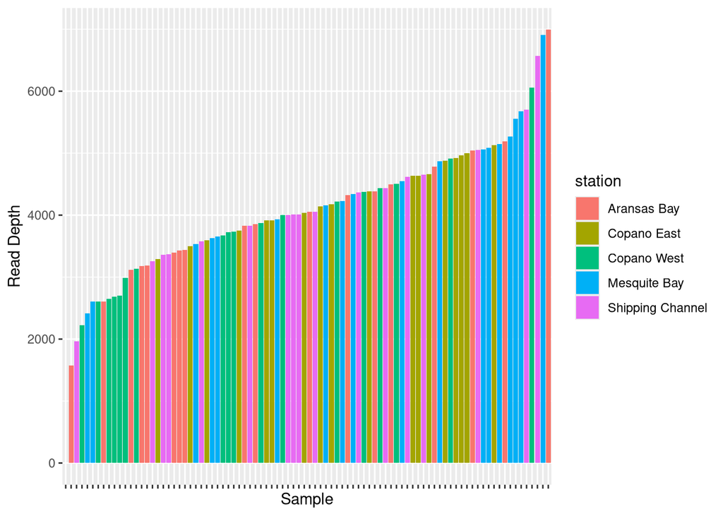

```r
# plot it as a bar plot
seqSums_df %>%
  ggplot(aes(x=reorder(names, TotalSeqs), y = TotalSeqs,
             fill = station)) +
  geom_bar(stat = "identity") +
  theme(axis.text.x = element_blank()) +
  labs(y = "Read Depth", x = "Sample")
```

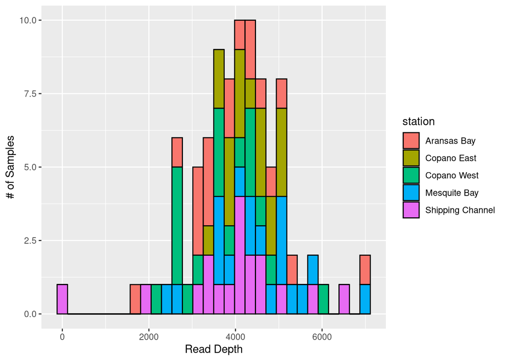

```r
# histogram
seqSums_df %>%
  ggplot(aes(x= TotalSeqs, fill = station)) +
  geom_histogram(color = "black") +
  labs(y = "# of Samples", x = "Read Depth")
```

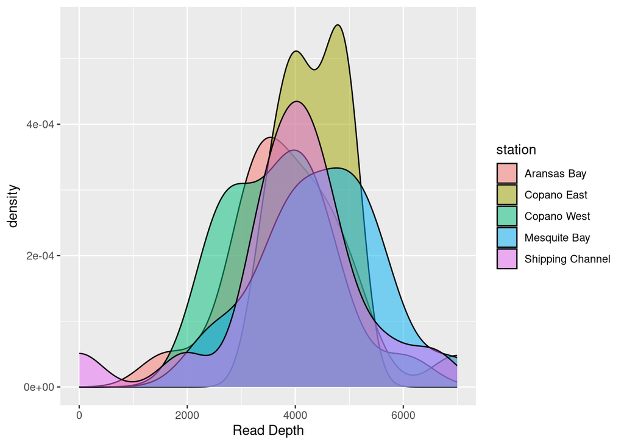

```r
# Density plot
seqSums_df %>%
  ggplot(aes(TotalSeqs, fill = station)) +
  geom_density(alpha = 0.5) +
  labs(x = "Read Depth")
```

# Remove samples with few reads

```r
# What's the min seq depth?
min(sample_sums(noControlsMock_ChlorosMitos_physeq))
```

```
## [1] 1
```

```r
# Remove 20210615-MA-SCB2F
raw_preprocessed_physeq <-
  noControlsMock_ChlorosMitos_physeq %>%
  subset_samples(., names != "20210615-MA-SCB2F")

#What's the new min seq depth?
min(sample_sums(raw_preprocessed_physeq))
```

```
## [1] 1576
```

```r
# Final check of the sequencing depth for now
# Here, we could remove more samples if we needed to
seqSums_df %>%
  dplyr::select(names, TotalSeqs) %>%
  arrange(TotalSeqs)
```

```
##                names TotalSeqs
## 1  20210615-MA-SCB2F         1
## 2  20210615-MA-ABB2F      1576
## 3  20210602-MA-SCB1P      1962
## 4  20210602-MA-CWS1P      2228
## 5  20210602-MA-MBB1P      2418
## 6  20210602-MA-MBS1P      2602
## 7  20211005-MA-CWS1P      2602
## 8  20210602-MA-ABB1P      2603
## 9  20211005-MA-CWB1W      2649
## 10 20210602-MA-CWB1F      2681
## 11 20211005-MA-CWS1W      2701
## 12 20211005-MA-CWB1P      2990
## 13 20210615-MA-ABB2P      3120
## 14 20211005-MA-CWB1F      3137
```

[output cut: 76 more lines]

# Save Preprocessed Phyloseq Object

```r
save(raw_preprocessed_physeq, file = "data/02_PreProcessing/raw_preprocessed_physeq.RData")
```

# Final info for Reproducibility

## Check Render Time

```r
# Take the time now that we are at the end of the script
end_time <- Sys.time()
end_time
```

```
## [1] "2025-03-12 13:53:59 EDT"
```

```r
# Echo the elapsed time
elapsed_time <- round((end_time - start_time), 3)
elapsed_time
```

```
## Time difference of 17.177 secs
```